# FitBit Fitness Tracker Data - Google Data Analytics Capstone

## **Analyze the Date.**

### Summary of the Data

Before summarizing the data, I want to find out how many distinct consumer IDs are reported in each of the datasets.

```
## [1] 33
```

```
## [1] 33
```

```
## [1] 24
```

I then examined the summary statistics of the three datasets: daily activity, daily steps, and sleep time.

```r
# In the daily activity dataset:
daily_activity %>%
  select(totalsteps, totaldistance, calories) %>%
  summary()
```

```
##    totalsteps    totaldistance       calories
##  Min.   :    0   Min.   : 0.000   Min.   :   0
##  1st Qu.: 3790   1st Qu.: 2.620   1st Qu.:1828
##  Median : 7406   Median : 5.245   Median :2134
##  Mean   : 7638   Mean   : 5.490   Mean   :2304
##  3rd Qu.:10727   3rd Qu.: 7.713   3rd Qu.:2793
##  Max.   :36019   Max.   :28.030   Max.   :4900
```

```r
#In the daily steps dataset:
daily_steps %>%
  select(steptotal) %>%
  summary()
```

```
##    steptotal
##  Min.   :    0
##  1st Qu.: 3790
##  Median : 7406
##  Mean   : 7638
##  3rd Qu.:10727
##  Max.   :36019
```

```r
# In the sleep time dataset:
sleep_time %>%
  select(totalminutesasleep, totaltimeinbed) %>%
  summary()
```

```
##  totalminutesasleep totaltimeinbed
##  Min.   : 58.0      Min.   : 61.0
##  1st Qu.:361.0      1st Qu.:403.0
##  Median :433.0      Median :463.0
##  Mean   :419.5      Mean   :458.6
##  3rd Qu.:490.0      3rd Qu.:526.0
##  Max.   :796.0      Max.   :961.0
```

### Merging the datasets

Merging the datasets will allow for further analysis of the trends and insights contained in each dataset, and create a holistic insight into the usage habits of the FitBit users sampled.

```r
# I am using the merge function, which works like an Inner JOIN. I will perform the merge in successive steps.
merged_data_temp <- merge(daily_activity, daily_steps, by = c("id", "date"))
merged_data <- merge(merged_data_temp, sleep_time, by = c("id", "date"))
head(merged_data)
```

```
##           id       date totalsteps totaldistance trackerdistance
## 1 1503960366 2016-04-12      13162          8.50            8.50
## 2 1503960366 2016-04-13      10735          6.97            6.97
## 3 1503960366 2016-04-15       9762          6.28            6.28
## 4 1503960366 2016-04-16      12669          8.16            8.16
## 5 1503960366 2016-04-17       9705          6.48            6.48
## 6 1503960366 2016-04-19      15506          9.88            9.88
##   loggedactivitiesdistance veryactivedistance moderatelyactivedistance
## 1                        0               1.88                     0.55
## 2                        0               1.57                     0.69
## 3                        0               2.14                     1.26
## 4                        0               2.71                     0.41
## 5                        0               3.19                     0.78
## 6                        0               3.53                     1.32
##   lightactivedistance sedentaryactivedistance veryactiveminutes
```

[output cut: 20 more lines]

Note: I performed the merge in successive steps because the merge function in R only accepts two data frames at a time. First, I merged daily activity with daily steps. Then, I merged this resulting data frame with the sleep time data frame.

Now, I want to know how many distinct users are in this new data frame.

```
## [1] 24
```

The results shows that the data frame includes data from 24 unique individuals.

Before proceeding to the analysis, I want to ensure that the numerical columns are indeed integers.

```r
merged_data$totalsteps <- as.integer(merged_data$totalsteps)
merged_data$totaldistance <- as.integer(merged_data$totaldistance)
merged_data$veryactivedistance <- as.integer(merged_data$veryactivedistance)
merged_data$lightactivedistance <- as.integer(merged_data$lightactivedistance)
merged_data$sedentaryactivedistance <- as.integer(merged_data$sedentaryactivedistance)
merged_data$calories <- as.integer(merged_data$calories)
merged_data$totalminutesasleep <- as.integer(merged_data$totalminutesasleep)
merged_data$moderatelyactivedistance <- as.integer(merged_data$moderatelyactivedistance)
```

## **Exploratory Data Analysis.**

In this section, I analyzed the usage activities of the 24 FitBit users in the following categories:

1. Daily activity trends analysis.
2. Correlation analysis.

### a. Daily Activity Trend Analysis (Daily Steps and Time Active)

#### Distribution of Daily Steps:

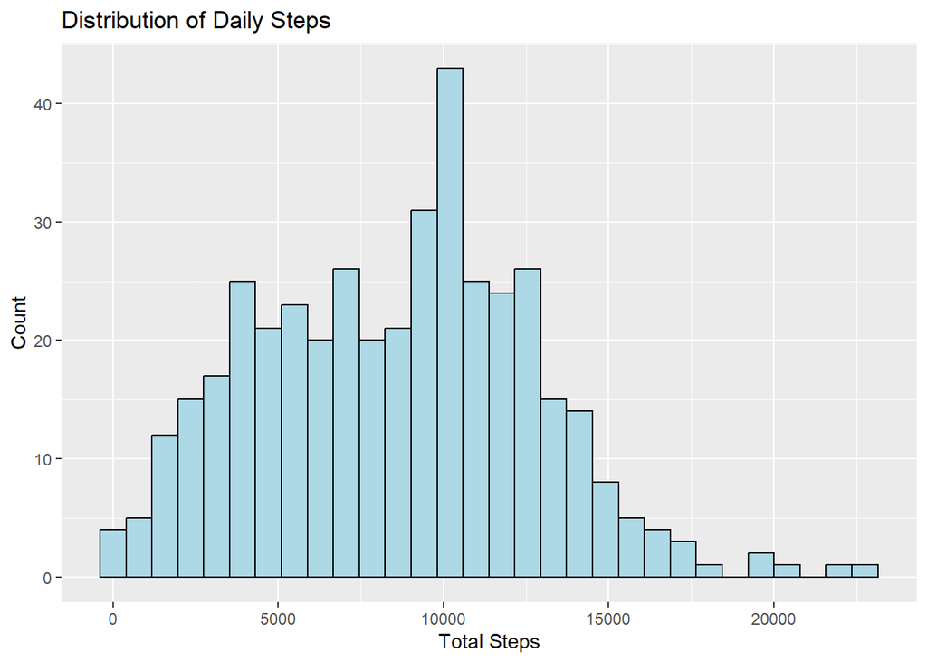

```r
# Plot showing the number of steps taken by users.
ggplot(data = merged_data) +
  geom_histogram(
    mapping = aes(x = totalsteps),
    bins = 30,
    color = "black",
    fill = "lightblue"
  ) +
  labs(title = "Distribution of Daily Steps", x = "Total Steps", y = "Count")
```

#### Distribution of active time:

Active time will be defined as the combination of the very active, fairly active, and lightly active minutes columns.

```r
# Merging the three active columns before creating the plot:
merged_data <- merged_data %>%
  mutate(total_active_minutes = veryactiveminutes + fairlyactiveminutes + lightlyactiveminutes)
```

Next, I created a plot showing the distribution of active time among users.

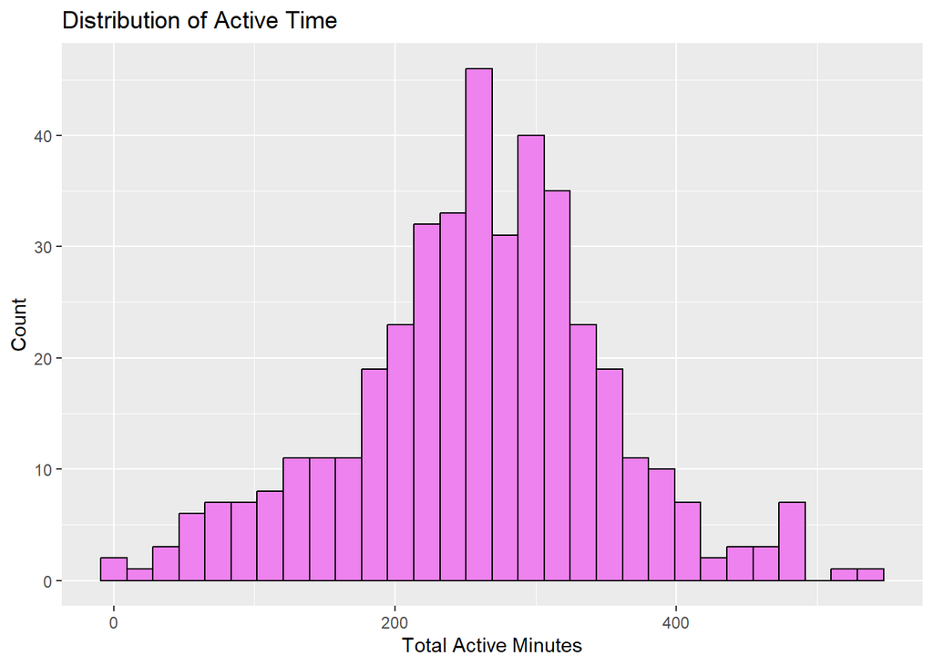

```r
# Plot showing the total active minutes among users.
ggplot(data = merged_data) +
  geom_histogram(mapping = aes(x = total_active_minutes), bins = 30, fill = "violet", color = "black") +
  labs(title = "Distribution of Active Time", x = "Total Active Minutes", y = "Count")
```

### b. Correlation Analysis

#### Correlation between time spent in bed and total active time:

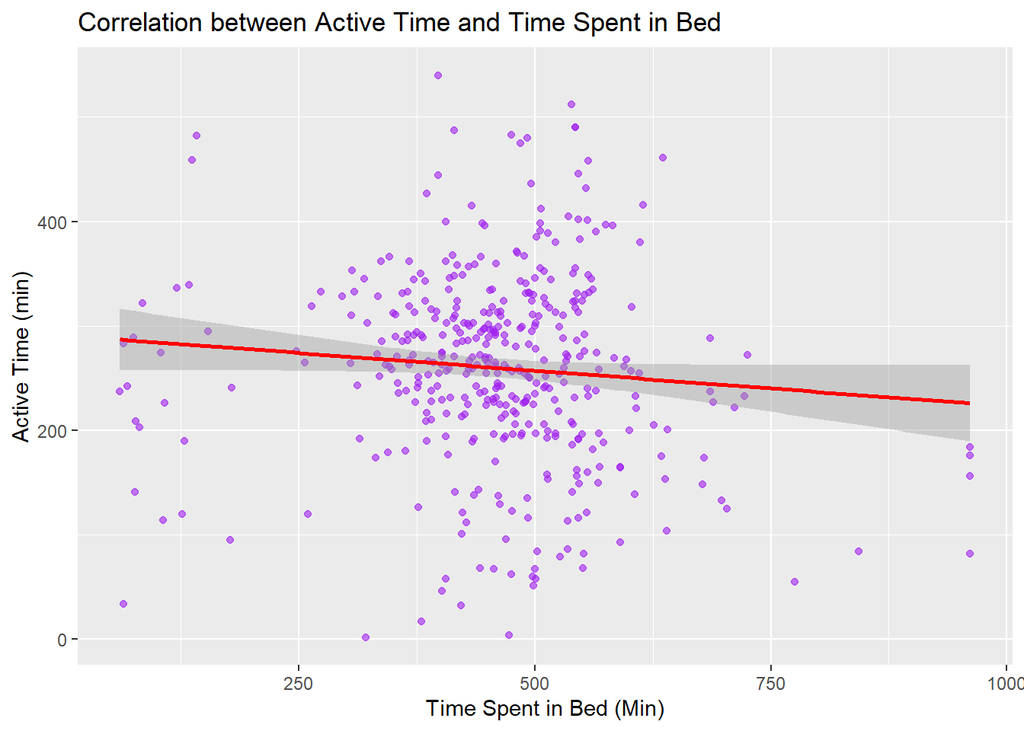

```r
# Correlation between time spent in bed and total active time:
ggplot(merged_data, aes(x = totaltimeinbed, y = total_active_minutes)) +
  geom_point(color = "purple", alpha = 0.6) +
  geom_smooth(method = "lm", color = "red", se = TRUE) +
  labs(
    title = "Correlation between Active Time and Time Spent in Bed",
    x = "Time Spent in Bed (Min)",
    y = "Active Time (min)"
    )
```

#### Observations:

- The trend line shows a slight negative slope, indicating a weak inverse relationship between time spent in bed and active time.
- There is significant variability in the data, indicating that the relationship between active time and time spent in bed is not strongly linear.
- Users spending the most time in bed (above 800 minutes) generally report lower active time.

#### Correlation between Total Active Time and Calories burned:

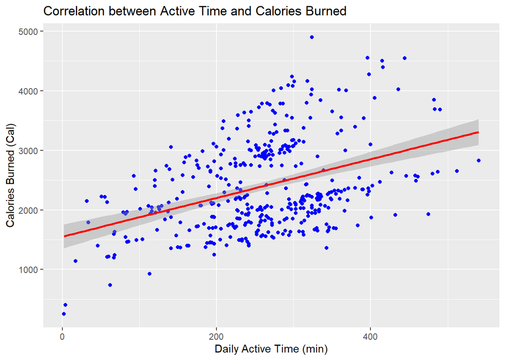

```r
#Scatter plot showing the correlation between active time and calories burned
ggplot(data = merged_data, aes(x = total_active_minutes, y = calories)) +
  geom_point(color = "blue") +
  geom_smooth(method = "lm", color = "red", se = TRUE) +  # Trend line with confidence interval
  labs(
    title = "Correlation between Active Time and Calories Burned",
    x = "Daily Active Time (min)",
    y = "Calories Burned (Cal)"
  )
```

#### Correlation between Time Spent Asleep and Calories burned:

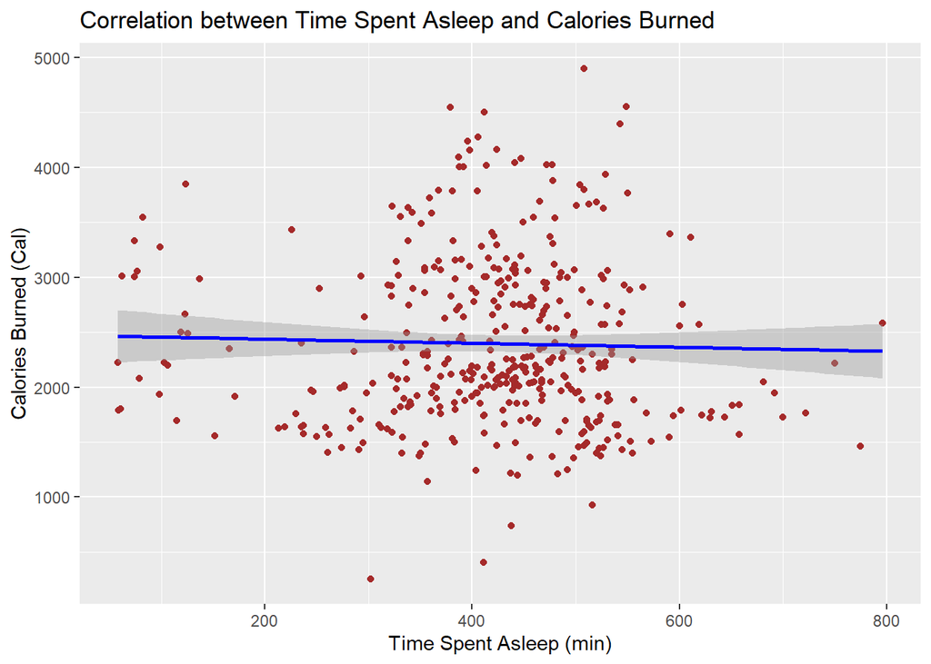

```r
# Correlation between time spent asleep and calories
ggplot(data = merged_data, aes(x = totalminutesasleep, y = calories)) +
  geom_point(color = "brown") +
  geom_smooth(method = "lm", color = "blue", se = TRUE) +  # Trend line with confidence interval
  labs(
    title = "Correlation between Time Spent Asleep and Calories Burned",
    x = "Time Spent Asleep (min)",
    y = "Calories Burned (Cal)"
  )
```

## **Key Findings and Recommendations.**

### Recommendations.

- **Create personalized goals:** Based on data from FitBit users, creating personalized fitness and activity goals may serve as a guide for users to follow. Using insights from this analysis, we can use 10,000 daily steps and 200 daily active minutes as defaults.
- **Set goals reminders:** Use reminders to encourage/motivate users to work on accomplishing the goals they have set.
- **Incorporate Machine Learning:** Use machine learning to generate personalized activity and sleep recommendations based on each user’s data trends. This ensures that recommendations change according to usage.
- **Sleep efficiency:** Add a tracker to distinguish between time spent in bed and actual sleep time. This system should also provide feedback, providing personalized suggestions to users with excessive time in bed (>10 hours) to improve their sleep quality and reduce sedentary behavior.
- **Data visualization:** Providing catchy dashboards will allow users track their activity, including steps, active minutes, calories burned and sleep. This dashboard should also show progress towards their stated goal for each category.

### References

- Deguenon, Rodrigue (2024). [Capstone Project: Bellabeat](https://www.kaggle.com/rodriguedeguenon)
- Mobius (2024). [FitBit Fitness Tracker Dataset](http://www.kaggle.com/datasets/arashnic/fitbit/data)